# A6: Clustering and Association Rule Mining

Prabhudatta Mohapatra

November 28, 2023

# 1 Task I

## 1.1 Code chunk 1: Load packages, prepare and inspect the data

```r
# setting up working directory
wd<- getwd()
setwd(wd)

# 1.A
# Loading libraries
library(knitr)
library(kernlab)
library(rJava)
library(RWeka)
library(rpart)
library(rpart.plot)
library(tidyverse)
library(caret)
library(C50)
library(rminer)
library(e1071)
library(matrixStats)
library(arules)
library(arulesViz)
library(tidyverse)
library(psych)

# Importing data with stringsAsFactors = False
data <- read.csv("Walmart_visits_7trips.csv", stringsAsFactors = FALSE)

# structure of the input file
str(data)
```

```
## 'data.frame':    12734 obs. of  9 variables:
##  $ TripType    : int  999 999 999 999 999 999 999 999 999 999 ...
##  $ DOW         : chr  "Friday" "Friday" "Friday" "Friday" ...
##  $ UniqueItems : int  1 2 1 1 2 1 1 1 1 1 ...
##  $ TotalQty    : int  0 1 0 0 3 0 0 0 1 0 ...
##  $ RtrnQty     : int  1 1 1 1 0 1 1 1 0 1 ...
##  $ NetQty      : int  -1 0 -1 -1 3 -1 -1 -1 1 -1 ...
##  $ UniqDepts   : int  1 1 1 1 2 1 1 1 1 1 ...
##  $ OneItemDepts: int  1 0 1 1 2 1 1 1 1 1 ...
##  $ RtrnDepts   : int  1 1 1 1 0 1 1 1 0 1 ...
```

```r
# transform all categorical variables to factors
data <- data %>% mutate(across(c(TripType,DOW),factor))

# summary of the input file
summary(data)
```

```
##  TripType          DOW        UniqueItems         TotalQty
##  5  :1106   Friday   :1851   Min.   :  1.000   Min.   :  0.000
##  7  :1305   Monday   :1765   1st Qu.:  1.000   1st Qu.:  1.000
##  8  :2808   Saturday :1923   Median :  2.000   Median :  3.000
##  9  :2046   Sunday   :2014   Mean   :  6.203   Mean   :  7.185
##  39 :2229   Thursday :1738   3rd Qu.:  7.000   3rd Qu.:  8.000
##  40 :1373   Tuesday  :1703   Max.   :113.000   Max.   :137.000
##  999:1867   Wednesday:1740
##     RtrnQty            NetQty          UniqDepts       OneItemDepts
##  Min.   : 0.0000   Min.   :-52.000   Min.   : 1.000   Min.   : 0.000
##  1st Qu.: 0.0000   1st Qu.:  1.000   1st Qu.: 1.000   1st Qu.: 1.000
##  Median : 0.0000   Median :  2.000   Median : 2.000   Median : 1.000
##  Mean   : 0.2431   Mean   :  6.942   Mean   : 3.194   Mean   : 1.918
##  3rd Qu.: 0.0000   3rd Qu.:  8.000   3rd Qu.: 4.000   3rd Qu.: 3.000
##  Max.   :52.0000   Max.   :137.000   Max.   :21.000   Max.   :12.000
##
##    RtrnDepts
##  Min.   : 0.0000
##  1st Qu.: 0.0000
##  Median : 0.0000
##  Mean   : 0.1756
##  3rd Qu.: 0.0000
##  Max.   :10.0000
##
```

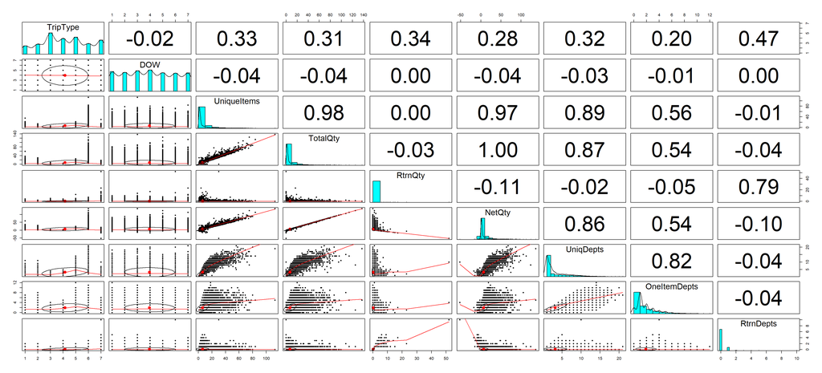

```r
# 1.B
# Correlation Analysis
pairs.panels(data)
```

```r
#1.C
#Decision Tree with a CF = 0.98
tree_cf_1 <- C5.0(TripType~.,data,control = C5.0Control(CF= 0.16))
tree_cf_1$size
```

```
## [1] 8
```

```r
summary(tree_cf_1)
```

```
##
## Call:
## C5.0.formula(formula = TripType ~ ., data = data, control = C5.0Control(CF
##  = 0.16))
##
##
## C5.0 [Release 2.07 GPL Edition]      Tue Nov 28 11:10:58 2023
## -------------------------------
##
## Class specified by attribute `outcome'
##
## Read 12734 cases (9 attributes) from undefined.data
##
## Decision tree:
##
## NetQty <= 3:
## :...NetQty <= 0: 999 (1345)
## :   NetQty > 0: 8 (6660/3899)
## NetQty > 3:
## :...NetQty > 19: 40 (1377/59)
##     NetQty <= 19:
##     :...UniqDepts > 2: 39 (2901/820)
##         UniqDepts <= 2:
##         :...UniqueItems <= 1: 5 (42/17)
##             UniqueItems > 1:
##             :...TotalQty > 5: 39 (157/106)
##                 TotalQty <= 5:
##                 :...UniqDepts <= 1: 5 (48/28)
##                     UniqDepts > 1: 7 (204/119)
##
##
## Evaluation on training data (12734 cases):
##
##      Decision Tree
##    ----------------
##    Size      Errors
##
##       8 5048(39.6%)   <<
##
##
##     (a)   (b)   (c)   (d)   (e)   (f)   (g)    <-classified as
##    ----  ----  ----  ----  ----  ----  ----
##      45    40   763         246    12          (a): class 5
##      20    85   674         522     4          (b): class 7
##       4    21  2761          22                (c): class 8
##            11  2020          15                (d): class 9
##      17    30     7        2132    43          (e): class 39
##             1                54  1318          (f): class 40
##       4    16   435          67        1345    (g): class 999
##
##
##  Attribute usage:
##
##  100.00% NetQty
##   26.32% UniqDepts
##    3.54% UniqueItems
##    3.21% TotalQty
##
##
## Time: 0.1 secs
```

```r
tree_cf_1_predictions <- predict(tree_cf_1,data)

# Confusion matrix for train data prediction
mmetric(data$TripType, tree_cf_1_predictions, metric="CONF")$conf
```

```
##       pred
## target    5    7    8    9   39   40  999
##    5     45   40  763    0  246   12    0
##    7     20   85  674    0  522    4    0
##    8      4   21 2761    0   22    0    0
##    9      0   11 2020    0   15    0    0
##    39    17   30    7    0 2132   43    0
##    40     0    1    0    0   54 1318    0
##    999    4   16  435    0   67    0 1345
```

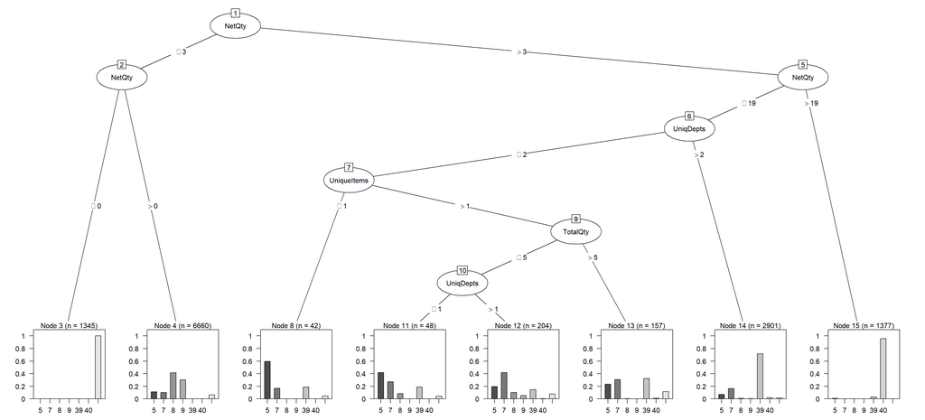

```r
#mmetric(data$TripType, tree_cf_1_predictions, metric = c("ACC","TPR","PRECISION","F1"))

# C5.0 Tree Plot
plot(tree_cf_1)
```

### 1.1.1 Data Exploration & Decision Tree

- Walmart Visit data has information about 12734 visits along with other details such as visit day of week, unique items purchased in that visit, total quantity etc.
- Categorical variables are converted to factors.
- Data structure and summary has been displayed.
- From the correlation analysis it can be observed that UniqueItems is highly correlated with NetQty and UniqDepts having correlation of 0.97 and 0.89 respectively. UniqDept is highly correlated with TotalQty and NetQty having correlation of 0.87 and 0.86 respectively. UniqueItems is highly correlated with TotalQty and NetQty having correlation of 0.98 and 0.97 respectively.
- A decision tree (C5.0) is built with 8 leaf nodes using CF of 0.16.

## 1.2 Code chunk 2: SimpleKMeans clustering to understand visits

```r
# 2.A
# Unique TripType number
TripType.levels <-length(unique(data$TripType))
# removing TripType
cdata<- data[,2:9]

# 2.B
# Cluster with default (random) initial cluster assignment and the default distance function (Euclidean)
kmeans1 <- SimpleKMeans(cdata,  Weka_control(N=TripType.levels, init = 0, V=TRUE))
kmeans1
```

```
##
## kMeans
## ======
##
## Number of iterations: 14
## Within cluster sum of squared errors: 3983.3256867784276
##
## Initial starting points (random):
##
## Cluster 0: Friday,4,0,4,-4,2,1,2
## Cluster 1: Wednesday,2,2,0,2,2,2,0
## Cluster 2: Thursday,1,0,1,-1,1,1,1
## Cluster 3: Wednesday,1,1,0,1,1,1,0
## Cluster 4: Sunday,1,1,1,0,1,1,1
## Cluster 5: Saturday,5,5,0,5,3,2,0
## Cluster 6: Friday,4,4,0,4,4,4,0
##
## Missing values globally replaced with mean/mode
##
## Final cluster centroids:
##                               Cluster#
## Attribute        Full Data           0           1           2           3           4           5           6
##                  (12734.0)    (1926.0)     (795.0)    (2359.0)    (2838.0)    (2319.0)    (1982.0)     (515.0)
## ==============================================================================================================
## DOW                 Sunday      Friday   Wednesday    Thursday   Wednesday      Sunday    Saturday      Friday
##   Friday       1851.0 ( 14%)1569.0 ( 81%)  0.0 (  0%)  0.0 (  0%)  0.0 (  0%)  0.0 (  0%)  0.0 (  0%)282.0 ( 54%)
##   Monday       1765.0 ( 13%)187.0 (  9%)216.0 ( 27%)320.0 ( 13%)707.0 ( 24%)158.0 (  6%) 35.0 (  1%)142.0 ( 27%)
##   Saturday     1923.0 ( 15%)  0.0 (  0%)  0.0 (  0%)  0.0 (  0%)  0.0 (  0%)  0.0 (  0%)1922.0 ( 96%)  1.0 (  0%)
##   Sunday       2014.0 ( 15%)  0.0 (  0%)  0.0 (  0%)  0.0 (  0%)  0.0 (  0%)2014.0 ( 86%)  0.0 (  0%)  0.0 (  0%)
##   Thursday     1738.0 ( 13%)  0.0 (  0%)  0.0 (  0%)1737.0 ( 73%)  0.0 (  0%)  0.0 (  0%)  0.0 (  0%)  1.0 (  0%)
##   Tuesday      1703.0 ( 13%)170.0 (  8%)210.0 ( 26%)302.0 ( 12%)760.0 ( 26%)147.0 (  6%) 25.0 (  1%) 89.0 ( 17%)
##   Wednesday    1740.0 ( 13%)  0.0 (  0%)369.0 ( 46%)  0.0 (  0%)1371.0 ( 48%)  0.0 (  0%)  0.0 (  0%)  0.0 (  0%)
##
## UniqueItems         6.2033      2.6651     14.1799      4.7512      2.0247      7.9461      6.7735     26.7592
##                  +/-9.1936   +/-2.8401   +/-8.4465   +/-7.3608   +/-1.6575  +/-10.1846    +/-9.323  +/-14.0425
##
## TotalQty            7.1849      2.8411     16.7157      5.5019      2.1945      9.2902      7.8158     32.0175
##                 +/-11.2831     +/-3.91  +/-10.7118   +/-9.3125   +/-2.2108   +/-12.458  +/-11.3376  +/-17.2611
##
## RtrnQty             0.2431      0.4361      0.2113       0.178      0.1853       0.229      0.2619      0.1786
##                  +/-0.9149   +/-0.9064   +/-1.9588   +/-0.5966   +/-0.8215    +/-0.808   +/-0.8843   +/-0.4783
##
## NetQty              6.9417       2.405     16.5044      5.3239      2.0092      9.0612       7.554     31.8388
##                 +/-11.3513   +/-4.1859  +/-10.9241   +/-9.3264   +/-2.3983  +/-12.5132  +/-11.4112  +/-17.1912
##
## UniqDepts           3.1938       1.812      7.2327      2.7897      1.4137      3.8482      3.4026     10.0369
##                  +/-3.0952   +/-1.2409   +/-2.0374   +/-2.4401   +/-0.7464   +/-3.2775   +/-3.1987   +/-2.6882
##
## OneItemDepts        1.9179      1.3032      4.2264      1.9262      0.9683      2.1458      1.9581       4.666
##                  +/-1.6439   +/-0.9011   +/-1.4281   +/-1.3618   +/-0.6762    +/-1.669   +/-1.6589   +/-2.0273
##
## RtrnDepts           0.1756      0.3344       0.122      0.1412      0.1163      0.1686      0.1821      0.1553
##                  +/-0.4553   +/-0.5473   +/-0.5254   +/-0.4035    +/-0.358   +/-0.4686    +/-0.473   +/-0.3935
```

```r
# 2.C
#  Cluster with number of clusters = TripType.levels, the distance = Euclidean distance, and initial cluster assignment is Kmeans++ method
kmeans2 <- SimpleKMeans(cdata, Weka_control(N=TripType.levels, init = 1, V=TRUE))
kmeans2
```

```
##
## kMeans
## ======
##
## Number of iterations: 22
## Within cluster sum of squared errors: 4012.5108332500567
##
## Initial starting points (k-means++):
##
## Cluster 0: Friday,4,0,4,-4,2,1,2
## Cluster 1: Wednesday,3,3,0,3,3,3,0
## Cluster 2: Tuesday,1,1,0,1,1,1,0
## Cluster 3: Sunday,3,4,0,4,3,3,0
## Cluster 4: Sunday,1,1,0,1,1,1,0
## Cluster 5: Saturday,3,3,0,3,3,3,0
## Cluster 6: Sunday,7,7,0,7,5,3,0
##
## Missing values globally replaced with mean/mode
##
## Final cluster centroids:
##                               Cluster#
## Attribute        Full Data           0           1           2           3           4           5           6
##                  (12734.0)    (1919.0)    (2418.0)    (1713.0)     (985.0)    (3117.0)    (2226.0)     (356.0)
## ==============================================================================================================
## DOW                 Sunday      Friday   Wednesday     Tuesday      Sunday      Sunday    Saturday      Sunday
##   Friday       1851.0 ( 14%)1851.0 ( 96%)  0.0 (  0%)  0.0 (  0%)  0.0 (  0%)  0.0 (  0%)  0.0 (  0%)  0.0 (  0%)
##   Monday       1765.0 ( 13%) 34.0 (  1%)332.0 ( 13%)  5.0 (  0%)273.0 ( 27%)863.0 ( 27%)153.0 (  6%)105.0 ( 29%)
##   Saturday     1923.0 ( 15%)  0.0 (  0%)  0.0 (  0%)  0.0 (  0%)  0.0 (  0%)  0.0 (  0%)1918.0 ( 86%)  5.0 (  1%)
##   Sunday       2014.0 ( 15%)  0.0 (  0%)  0.0 (  0%)  0.0 (  0%)496.0 ( 50%)1353.0 ( 43%)  0.0 (  0%)165.0 ( 46%)
##   Thursday     1738.0 ( 13%) 34.0 (  1%)348.0 ( 14%)  6.0 (  0%)216.0 ( 21%)901.0 ( 28%)155.0 (  6%) 78.0 ( 21%)
##   Tuesday      1703.0 ( 13%)  0.0 (  0%)  0.0 (  0%)1702.0 ( 99%)  0.0 (  0%)  0.0 (  0%)  0.0 (  0%)  1.0 (  0%)
##   Wednesday    1740.0 ( 13%)  0.0 (  0%)1738.0 ( 71%)  0.0 (  0%)  0.0 (  0%)  0.0 (  0%)  0.0 (  0%)  2.0 (  0%)
##
## UniqueItems         6.2033      5.8223      4.4438      5.4513     13.3157      1.9695       6.894     36.8989
##                  +/-9.1936   +/-8.4507   +/-6.4714   +/-8.0628   +/-5.9249   +/-1.7448   +/-8.5702  +/-13.8774
##
## TotalQty            7.1849      6.8312      5.0211      6.2633     15.6132      2.0873      8.0139     44.3511
##                 +/-11.2831  +/-10.4718   +/-7.8996   +/-9.8533   +/-7.4901    +/-2.391  +/-10.5152  +/-18.1799
##
## RtrnQty             0.2431      0.2163      0.2151       0.258      0.1594      0.2913      0.2439      0.3118
##                  +/-0.9149   +/-0.7028   +/-0.8177   +/-1.4701   +/-0.6502    +/-0.829   +/-0.8534   +/-0.7438
##
## NetQty              6.9417      6.6149       4.806      6.0053     15.4538       1.796        7.77     44.0393
##                 +/-11.3513  +/-10.5405   +/-7.9509  +/-10.0445   +/-7.5348   +/-2.6281  +/-10.6032   +/-18.109
##
## UniqDepts           3.1938      3.0177      2.7506      2.9475      6.9066       1.368      3.5234     11.9916
##                  +/-3.0952   +/-2.9219   +/-2.3871   +/-2.7893   +/-1.6359   +/-0.6973     +/-2.99   +/-2.4165
##
## OneItemDepts        1.9179      1.8015      1.9467      1.8389      3.9259      0.9599      2.0184      4.9326
##                  +/-1.6439   +/-1.6116   +/-1.3431   +/-1.6053   +/-1.4704   +/-0.6262   +/-1.5893   +/-2.0952
##
## RtrnDepts           0.1756      0.1584      0.1667      0.1646      0.1259      0.2092      0.1716        0.25
##                  +/-0.4553   +/-0.4222   +/-0.4557   +/-0.4746   +/-0.4376   +/-0.4524   +/-0.4656   +/-0.5111
```

```r
# 2.D
#Clustering with number of cluster = TripType.levels, initial cluster assignment is Kmeans++ method, and the distance = "weka.core.ManhattanDistance"
kmeans3 <- SimpleKMeans(cdata, Weka_control(N=TripType.levels, init = 1, V= TRUE, A = "weka.core.ManhattanDistance"))
kmeans3
```

```
##
## kMeans
## ======
##
## Number of iterations: 15
## Sum of within cluster distances: 6719.908977218368
##
## Initial starting points (k-means++):
##
## Cluster 0: Friday,4,0,4,-4,2,1,2
## Cluster 1: Wednesday,2,3,0,3,2,2,0
## Cluster 2: Monday,2,2,0,2,2,2,0
## Cluster 3: Sunday,1,1,0,1,1,1,0
## Cluster 4: Friday,2,2,0,2,1,0,0
## Cluster 5: Thursday,25,26,0,26,9,3,0
## Cluster 6: Sunday,9,10,0,10,7,6,0
##
## Missing values globally replaced with mean/mode
##
## Final cluster centroids:
##                               Cluster#
## Attribute        Full Data           0           1           2           3           4           5           6
##                  (12734.0)    (1169.0)    (2049.0)    (2125.0)    (2561.0)    (1715.0)    (2045.0)    (1070.0)
## ==============================================================================================================
## DOW                 Sunday      Friday   Wednesday      Monday      Sunday      Friday    Thursday      Sunday
##   Friday       1851.0 ( 14%)579.0 ( 49%)  0.0 (  0%)  0.0 (  0%)  0.0 (  0%)1272.0 ( 74%)  0.0 (  0%)  0.0 (  0%)
##   Monday       1765.0 ( 13%)  0.0 (  0%)  0.0 (  0%)1765.0 ( 83%)  0.0 (  0%)  0.0 (  0%)  0.0 (  0%)  0.0 (  0%)
##   Saturday     1923.0 ( 15%)315.0 ( 26%)150.0 (  7%)193.0 (  9%)566.0 ( 22%)220.0 ( 12%)195.0 (  9%)284.0 ( 26%)
##   Sunday       2014.0 ( 15%)  0.0 (  0%)  0.0 (  0%)  0.0 (  0%)1448.0 ( 56%)  0.0 (  0%)  0.0 (  0%)566.0 ( 52%)
##   Thursday     1738.0 ( 13%)  0.0 (  0%)  0.0 (  0%)  0.0 (  0%)  0.0 (  0%)  0.0 (  0%)1687.0 ( 82%) 51.0 (  4%)
##   Tuesday      1703.0 ( 13%)275.0 ( 23%)159.0 (  7%)167.0 (  7%)547.0 ( 21%)223.0 ( 13%)163.0 (  7%)169.0 ( 15%)
##   Wednesday    1740.0 ( 13%)  0.0 (  0%)1740.0 ( 84%)  0.0 (  0%)  0.0 (  0%)  0.0 (  0%)  0.0 (  0%)  0.0 (  0%)
##
## UniqueItems              2          10           2           2           1           2           3          20
##                  +/-9.1936   +/-8.8363   +/-7.2403   +/-9.0595   +/-1.9094   +/-1.2026   +/-6.1102  +/-12.9739
##
## TotalQty                 3          11           3           2           1           2           3          24
##                 +/-11.2831  +/-11.2063   +/-8.8913  +/-11.0409   +/-2.5072   +/-1.9376   +/-7.9809  +/-16.0402
##
## RtrnQty                  0           0           0           0           0           0           0           0
##                  +/-0.9149   +/-0.5421   +/-0.8702   +/-0.8071   +/-0.8856   +/-0.7224   +/-0.8244   +/-1.6892
##
## NetQty                   2          11           3           2           1           2           3          24
##                 +/-11.3513  +/-11.2001   +/-8.9299  +/-11.1051   +/-2.7911   +/-2.1764   +/-8.0788  +/-16.1197
##
## UniqDepts                2           5           2           2           1           1           2           9
##                  +/-3.0952   +/-2.3526   +/-2.6134   +/-2.9729   +/-0.9383   +/-0.5359   +/-2.1538   +/-2.7216
##
## OneItemDepts             1           3           2           2           1           1           1           4
##                  +/-1.6439   +/-1.6097   +/-1.4613   +/-1.5243   +/-0.7255   +/-0.6736   +/-1.3203    +/-1.837
##
## RtrnDepts                0           0           0           0           0           0           0           0
##                  +/-0.4553   +/-0.3825   +/-0.4383   +/-0.4804   +/-0.4832   +/-0.4011   +/-0.4523    +/-0.506
```

```r
# 2.E
# Clustering with number of cluster = 5, random initial cluster assignment, and distance = "weka.core.ManhattanDistance"
kmeans4<- SimpleKMeans(cdata, Weka_control(N=5, init = 0, V= TRUE, A = "weka.core.ManhattanDistance"))
kmeans4
```

```
##
## kMeans
## ======
##
## Number of iterations: 5
## Sum of within cluster distances: 7533.174712648783
##
## Initial starting points (random):
##
## Cluster 0: Friday,4,0,4,-4,2,1,2
## Cluster 1: Wednesday,2,2,0,2,2,2,0
## Cluster 2: Thursday,1,0,1,-1,1,1,1
## Cluster 3: Wednesday,1,1,0,1,1,1,0
## Cluster 4: Sunday,1,1,1,0,1,1,1
##
## Missing values globally replaced with mean/mode
##
## Final cluster centroids:
##                               Cluster#
## Attribute        Full Data           0           1           2           3           4
##                  (12734.0)    (2446.0)    (2987.0)    (2158.0)    (2822.0)    (2321.0)
## ======================================================================================
## DOW                 Sunday      Friday    Saturday    Thursday   Wednesday      Sunday
##   Friday       1851.0 ( 14%)1851.0 ( 75%)  0.0 (  0%)  0.0 (  0%)  0.0 (  0%)  0.0 (  0%)
##   Monday       1765.0 ( 13%)304.0 ( 12%)577.0 ( 19%)197.0 (  9%)535.0 ( 18%)152.0 (  6%)
##   Saturday     1923.0 ( 15%)  0.0 (  0%)1923.0 ( 64%)  0.0 (  0%)  0.0 (  0%)  0.0 (  0%)
##   Sunday       2014.0 ( 15%)  0.0 (  0%)  0.0 (  0%)  0.0 (  0%)  0.0 (  0%)2014.0 ( 86%)
##   Thursday     1738.0 ( 13%)  0.0 (  0%)  0.0 (  0%)1738.0 ( 80%)  0.0 (  0%)  0.0 (  0%)
##   Tuesday      1703.0 ( 13%)291.0 ( 11%)487.0 ( 16%)223.0 ( 10%)547.0 ( 19%)155.0 (  6%)
##   Wednesday    1740.0 ( 13%)  0.0 (  0%)  0.0 (  0%)  0.0 (  0%)1740.0 ( 61%)  0.0 (  0%)
##
## UniqueItems              2           2           6           2           1           3
##                  +/-9.1936   +/-7.6229  +/-11.2768   +/-7.8145   +/-6.4662  +/-10.1096
##
## TotalQty                 3           2           7           2           1           3
##                 +/-11.2831   +/-9.4514  +/-13.7135   +/-9.9676   +/-7.9642  +/-12.2806
##
## RtrnQty                  0           0           0           0           0           0
##                  +/-0.9149   +/-0.6985   +/-1.2374   +/-0.6402   +/-0.9043   +/-0.8525
##
## NetQty                   2           2           6           2           1           3
##                 +/-11.3513   +/-9.5173  +/-13.8114   +/-9.9791   +/-8.0551  +/-12.3374
##
## UniqDepts                2           2           4           1           1           2
##                  +/-3.0952   +/-2.6157   +/-3.5696   +/-2.6524   +/-2.4106   +/-3.2878
##
## OneItemDepts             1           2           2           1           1           1
##                  +/-1.6439   +/-1.4445    +/-1.898    +/-1.539   +/-1.3014   +/-1.6849
##
## RtrnDepts                0           0           0           0           0           0
##                  +/-0.4553   +/-0.4377   +/-0.4829   +/-0.4144   +/-0.4581    +/-0.466
```

```r
# Clustering with number of cluster = 5, initial cluster assignment is Kmeans++ method, and distance = "weka.core.ManhattanDistance"
kmeans5<- SimpleKMeans(cdata, Weka_control(N=5, init = 1, V= TRUE, A = "weka.core.ManhattanDistance"))
kmeans5
```

```
##
## kMeans
## ======
##
## Number of iterations: 8
## Sum of within cluster distances: 7536.098130174797
##
## Initial starting points (k-means++):
##
## Cluster 0: Friday,4,0,4,-4,2,1,2
## Cluster 1: Wednesday,2,3,0,3,2,2,0
## Cluster 2: Monday,2,2,0,2,2,2,0
## Cluster 3: Sunday,1,1,0,1,1,1,0
## Cluster 4: Friday,2,2,0,2,1,0,0
##
## Missing values globally replaced with mean/mode
##
## Final cluster centroids:
##                               Cluster#
## Attribute        Full Data           0           1           2           3           4
##                  (12734.0)    (2928.0)    (2053.0)    (2347.0)    (3106.0)    (2300.0)
## ======================================================================================
## DOW                 Sunday    Saturday   Wednesday      Monday      Sunday      Friday
##   Friday       1851.0 ( 14%)  0.0 (  0%)  0.0 (  0%)  0.0 (  0%)  0.0 (  0%)1851.0 ( 80%)
##   Monday       1765.0 ( 13%)  0.0 (  0%)  0.0 (  0%)1765.0 ( 75%)  0.0 (  0%)  0.0 (  0%)
##   Saturday     1923.0 ( 15%)1923.0 ( 65%)  0.0 (  0%)  0.0 (  0%)  0.0 (  0%)  0.0 (  0%)
##   Sunday       2014.0 ( 15%)  0.0 (  0%)  0.0 (  0%)  0.0 (  0%)2014.0 ( 64%)  0.0 (  0%)
##   Thursday     1738.0 ( 13%)501.0 ( 17%)158.0 (  7%)308.0 ( 13%)545.0 ( 17%)226.0 (  9%)
##   Tuesday      1703.0 ( 13%)504.0 ( 17%)155.0 (  7%)274.0 ( 11%)547.0 ( 17%)223.0 (  9%)
##   Wednesday    1740.0 ( 13%)  0.0 (  0%)1740.0 ( 84%)  0.0 (  0%)  0.0 (  0%)  0.0 (  0%)
##
## UniqueItems              2           5           3           2           1           2
##                  +/-9.1936  +/-10.9176   +/-7.2328   +/-8.6689   +/-9.2212   +/-7.8627
##
## TotalQty                 3           6           3           2           1           2
##                 +/-11.2831  +/-13.5226   +/-8.9286  +/-10.5532  +/-11.1978   +/-9.7064
##
## RtrnQty                  0           0           0           0           0           0
##                  +/-0.9149   +/-1.2305   +/-0.9157   +/-0.7405   +/-0.8264   +/-0.6876
##
## NetQty                   2           6           3           2           1           2
##                 +/-11.3513  +/-13.6114   +/-8.9901  +/-10.6024  +/-11.2745   +/-9.7585
##
## UniqDepts                2           4           2           2           1           1
##                  +/-3.0952    +/-3.459   +/-2.6209   +/-2.8348    +/-3.088   +/-2.7847
##
## OneItemDepts             1           2           1           2           1           1
##                  +/-1.6439   +/-1.8576   +/-1.4828   +/-1.4721   +/-1.5113   +/-1.6022
##
## RtrnDepts                0           0           0           0           0           0
##                  +/-0.4553    +/-0.477   +/-0.4565   +/-0.4605   +/-0.4664   +/-0.3981
```

### 1.2.1 Kmeans clustering

- Multiple Kmeans clustering has been built and standard deviations and the centroids of the clusters has been calculated:
  1. Cluster with default (random) initial cluster assignment and the default distance function (Euclidean)
  2. Cluster with 7 clusters, Euclidean distance, and initial cluster assignment method is Kmeans++
  3. Cluster with 7 clusters, initial cluster assignment method is Kmeans++ and distance is weka.core.ManhattanDistance
  4. Cluster with 5 clusters, random initial cluster assignment, and distance is weka.core.ManhattanDistance
  5. Cluster with 5 clusters, initial cluster assignment method is Kmeans++, and distance is weka.core.ManhattanDistance

## 1.3 Code Chunk 3: Market Basket Analysis

```r
# 3.A
# Import data
Dept_baskets<- read.transactions("Walmart_baskets_1week.csv", format="single", sep = ",", header = TRUE, cols=c("VisitNumber","DepartmentDescription"))

summary(Dept_baskets)
```

```
## transactions as itemMatrix in sparse format with
##  2000 rows (elements/itemsets/transactions) and
##  66 columns (items) and a density of 0.0507803
##
## most frequent items:
##         DSD GROCERY   GROCERY DRY GOODS IMPULSE MERCHANDISE             PRODUCE
##                 612                 433                 414                 386
##               DAIRY             (Other)
##                 384                4474
##
## element (itemset/transaction) length distribution:
## sizes
##   1   2   3   4   5   6   7   8   9  10  11  12  13  14  15  16  17
## 693 372 246 173 127 112  70  67  49  34  20   9  12   9   2   3   2
##
##    Min. 1st Qu.  Median    Mean 3rd Qu.    Max.
##   1.000   1.000   2.000   3.352   5.000  17.000
##
## includes extended item information - examples:
##        labels
## 1  1-HR PHOTO
## 2 ACCESSORIES
## 3  AUTOMOTIVE
##
## includes extended transaction information - examples:
##   transactionID
## 1         10009
## 2         10034
## 3         10051
```

```r
# 3.B
# Inspect first 15 transactions
inspect(Dept_baskets[0:15])
```

```
##      items                         transactionID
## [1]  {IMPULSE MERCHANDISE}                 10009
## [2]  {CANDY, TOBACCO, COOKIES,
##       HOME MANAGEMENT,
##       JEWELRY AND SUNGLASSES,
##       MENS WEAR}                           10034
## [3]  {GIRLS WEAR, 4-6X  AND 7-14,
##       GROCERY DRY GOODS,
##       IMPULSE MERCHANDISE,
##       PERSONAL CARE}                       10051
## [4]  {OTHER DEPARTMENTS}                   10118
## [5]  {FINANCIAL SERVICES}                  10167
## [6]  {DAIRY,
##       DSD GROCERY,
##       FROZEN FOODS,
##       GROCERY DRY GOODS,
##       MEAT - FRESH & FROZEN,
##       PERSONAL CARE,
##       PRE PACKED DELI,
##       SLEEPWEAR/FOUNDATIONS}               10178
## [7]  {PHARMACY OTC}                        10191
## [8]  {FINANCIAL SERVICES}                  10206
## [9]  {INFANT CONSUMABLE HARDLINES}         1022
## [10] {CELEBRATION,
##       FABRICS AND CRAFTS,
##       OFFICE SUPPLIES,
##       TOYS}                                10250
## [11] {PHARMACY OTC}                        10272
## [12] {FABRICS AND CRAFTS,
##       GROCERY DRY GOODS,
##       PRODUCE}                             10273
## [13] {SERVICE DELI}                        1029
## [14] {BEAUTY,
##       DSD GROCERY,
##       GROCERY DRY GOODS,
##       HOME DECOR,
##       HOME MANAGEMENT,
##       HOUSEHOLD CHEMICALS/SUPP,
##       HOUSEHOLD PAPER GOODS,
##       LAWN AND GARDEN,
##       PAINT AND ACCESSORIES,
##       PERSONAL CARE,
##       PETS AND SUPPLIES}                   10296
## [15] {BEAUTY}                              10302
```

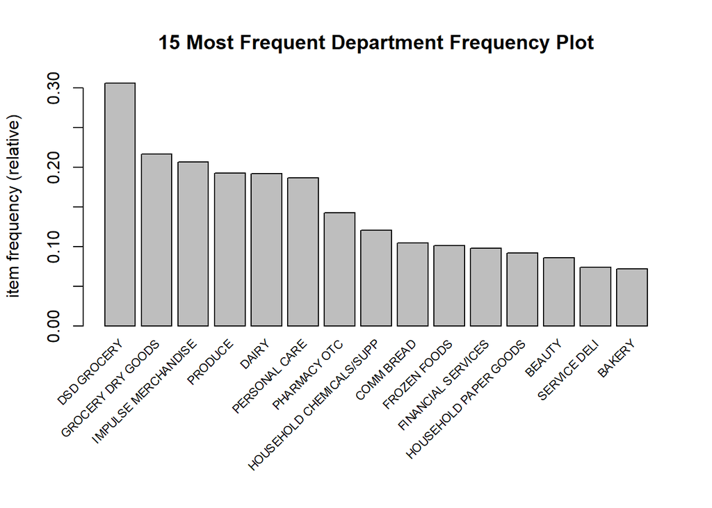

```r
# 3.C
# ItemFrequencyPlot of most frequent 15 items in descending order of transaction frequency
itemFrequencyPlot(Dept_baskets,topN = 15,type='relative', cex.names = 0.7, main="15 Most Frequent Department Frequency Plot")
```

```r
# 3.D.i
# buidling apriori rules (50-100)
mba_rules1<- apriori(Dept_baskets,parameter = list(support = 0.04, confidence = 0.5, minlen = 2))
```

```
## Apriori
##
## Parameter specification:
##  confidence minval smax arem  aval originalSupport maxtime support minlen
##         0.5    0.1    1 none FALSE            TRUE       5    0.04      2
##  maxlen target  ext
##      10  rules TRUE
##
## Algorithmic control:
##  filter tree heap memopt load sort verbose
##     0.1 TRUE TRUE  FALSE TRUE    2    TRUE
##
## Absolute minimum support count: 80
##
## set item appearances ...[0 item(s)] done [0.00s].
## set transactions ...[66 item(s), 2000 transaction(s)] done [0.00s].
## sorting and recoding items ... [25 item(s)] done [0.00s].
## creating transaction tree ... done [0.00s].
## checking subsets of size 1 2 3 4 5 done [0.00s].
## writing ... [86 rule(s)] done [0.00s].
## creating S4 object  ... done [0.00s].
```

```r
# number of rules - 86
mba_rules1
```

```
## set of 86 rules
```

```r
# rules summary
summary(mba_rules1)
```

```
## set of 86 rules
##
## rule length distribution (lhs + rhs):sizes
##  2  3  4
## 27 36 23
##
##    Min. 1st Qu.  Median    Mean 3rd Qu.    Max.
##   2.000   2.000   3.000   2.953   4.000   4.000
##
## summary of quality measures:
##     support          confidence        coverage            lift
##  Min.   :0.04050   Min.   :0.5078   Min.   :0.04450   Min.   :1.769
##  1st Qu.:0.04450   1st Qu.:0.6155   1st Qu.:0.05900   1st Qu.:2.677
##  Median :0.05125   Median :0.7160   Median :0.07250   Median :3.297
##  Mean   :0.05935   Mean   :0.7131   Mean   :0.08768   Mean   :3.298
##  3rd Qu.:0.07050   3rd Qu.:0.8081   3rd Qu.:0.10350   3rd Qu.:3.852
##  Max.   :0.13050   Max.   :0.9327   Max.   :0.21650   Max.   :5.471
##      count
##  Min.   : 81.0
##  1st Qu.: 89.0
##  Median :102.5
##  Mean   :118.7
##  3rd Qu.:141.0
##  Max.   :261.0
##
## mining info:
##          data ntransactions support confidence
##  Dept_baskets          2000    0.04        0.5
##                                                                                          call
##  apriori(data = Dept_baskets, parameter = list(support = 0.04, confidence = 0.5, minlen = 2))
```